# Assignment 3

### 1.)

```r
fruitflies = read.table("fruitflies.txt",header=TRUE)
fruitflies$loglongevity = log(fruitflies$longevity)
fruitflies$activity = as.factor(fruitflies$activity);attach(fruitflies)
head(fruitflies)
```

A data.frame: 6 × 4

|  | thorax <dbl> | longevity <int> | activity <fct> | loglongevity <dbl> |
| --- | --- | --- | --- | --- |
| 1 | 0.64 | 40 | isolated | 3.688879 |
| 2 | 0.70 | 37 | isolated | 3.610918 |
| 3 | 0.72 | 44 | isolated | 3.784190 |
| 4 | 0.72 | 47 | isolated | 3.850148 |
| 5 | 0.72 | 47 | isolated | 3.850148 |
| 6 | 0.76 | 47 | isolated | 3.850148 |

a) Make an informative plot of the data. Investigate whether sexual activity influences longevity by performing a statistical test, without taking the thorax length into account.

- Thorax can only be measured, but not controlled.

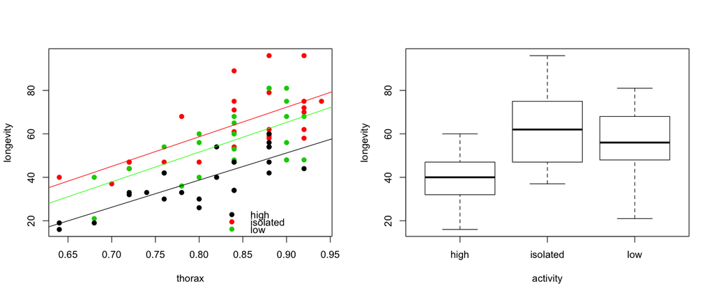

```r
par(mfrow=c(1,2));options(repr.plot.width=12, repr.plot.height=5)
plot(longevity~thorax,col=activity, pch=19)
abline(lm(longevity~thorax, data=df[df$activity=="high", ]),col = "black");
abline(lm(longevity~thorax, data=df[df$activity=="isolated", ]),col = "red");
abline(lm(longevity~thorax, data=df[df$activity=="low", ]),col = "green");
legend("bottomright", legend = c("high","isolated","low"), col = 1:3, pch = 19, bty = "n")
boxplot(longevity~activity)
```

A one-way ANOVA test was performed to investigate whether sexual activity influences longevity. Given that we have 3 different types of `sexual activity`, we call the population means for each group $\mu_1, \mu_2, \mu_3$. Our hypotheses are:

$H_0 : \mu_1 = \mu_2 = \mu_3$

$H_1 : \mu_i \neq \mu_j$ for some $(i,j)$

The chosen test is a one-way ANOVA (because we are looking at one factor's influence on one numerical outcome), with test statistic F, which has a f distribution (df= 2, 72) under $H_0$.

```r
model = lm(loglongevity~activity, data=fruitflies)
round(anova(model),3)
```

A anova: 2 × 5

|  | Df <dbl> | Sum Sq <dbl> | Mean Sq <dbl> | F value <dbl> | Pr(>F) <dbl> |
| --- | --- | --- | --- | --- | --- |
| activity | 2 | 3.666 | 1.833 | 19.421 | 0 |
| Residuals | 72 | 6.797 | 0.094 | NA | NA |

Results show that sexual activity has a significant effect on the loglongevity. $H_0$ is rejected.

We reject $H_0$, which states that the factor has no effect. The factor effect is significant according to one way anova.

```r
print(round(summary(model)$coefficients,3))
```

```
                 Estimate Std. Error t value Pr(>|t|)
(Intercept)         3.602      0.061  58.621        0
activityisolated    0.517      0.087   5.952        0
activitylow         0.398      0.087   4.577        0
```

```r
activity_high = exp(summary(model)$coef[1])
activity_isolated = exp(summary(model)$coef[1]) + exp(summary(model)$coef[2])
activity_low = exp(summary(model)$coef[1]) + exp(summary(model)$coef[3])
```

$\hat{\mu_{high}} = e^{3.602} = 36.67$

As can been seen from the computations, the number of days until death increases when the sexual activity decreases from high, to low, to isolated.

This one-way ANOVA test relies on the assumption that the residuals are normally distributed, with equal variances ($e$ ~ $N(0,\sigma)$). We check these assumptions here:

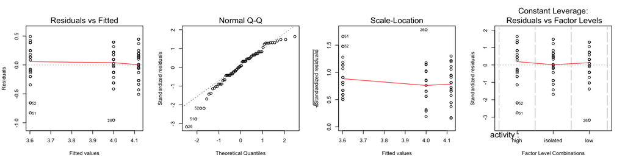

```r
options(repr.plot.width=13, repr.plot.height=3.4);par(mfrow=c(1,4
                                                            ));
plot(model)
```

```r
shapiro.test(residuals(model))
```

```
	Shapiro-Wilk normality test

data:  residuals(model)
W = 0.95431, p-value = 0.008652
```

We perform a Kruskal-Wallis test as the assumption of normality of the residuals was not met. Here we assume that we sample independently from a different population ($F_1, F_2, F_2$) for each condition of sexual activity.

Our hypotheses are:

$H_0 : F_1 = F_2 = F_3$

$H_1 : F_i \neq F_j$ for some $(i,j)$

```r
kruskal.test(fruitflies$loglongevity, fruitflies$activity)
```

```
	Kruskal-Wallis rank sum test

data:  fruitflies$loglongevity and fruitflies$activity
Kruskal-Wallis chi-squared = 27.444, df = 2, p-value = 1.098e-06
```

**b)** To investigate whether sexual activity influences loglongevity, including thorax length, a ANCOVA test was performed. The thorax length was added as an explanatory variable in the previous ANOVA test.

$H_A : \alpha_i = 0$ for all i, where $\alpha_i$ is the main effect of sexual activity at level i

$H_B : \beta = 0$ , where $\beta$ is the main effect of thorax length

$H_{1A} : \alpha_i \neq 0$ for some i

$H_{1B} : \beta \neq 0$

```r
model = lm(loglongevity~thorax+activity,data=fruitflies);
round(drop1(model, test="F"),3)
```

A anova: 3 × 6

|  | Df <dbl> | Sum of Sq <dbl> | RSS <dbl> | AIC <dbl> | F value <dbl> | Pr(>F) <dbl> |
| --- | --- | --- | --- | --- | --- | --- |
| <none> | NA | NA | 2.918 | -235.495 | NA | NA |
| thorax | 1 | 3.879 | 6.797 | -174.080 | 94.373 | 0 |
| activity | 2 | 2.113 | 5.031 | -198.642 | 25.705 | 0 |

```r
summary(model)
```

```
Call:
lm(formula = loglongevity ~ thorax + activity, data = fruitflies)

Residuals:
    Min      1Q  Median      3Q     Max
-0.4858 -0.1612  0.0104  0.1510  0.3574

Coefficients:
                 Estimate Std. Error t value Pr(>|t|)
(Intercept)       1.21893    0.24865   4.902 5.79e-06 ***
thorax            2.97899    0.30665   9.715 1.14e-14 ***
activityisolated  0.40998    0.05839   7.021 1.07e-09 ***
activitylow       0.28570    0.05849   4.885 6.18e-06 ***
---
Signif. codes:  0 ‘***’ 0.001 ‘**’ 0.01 ‘*’ 0.05 ‘.’ 0.1 ‘ ’ 1

Residual standard error: 0.2027 on 71 degrees of freedom
Multiple R-squared:  0.7211,	Adjusted R-squared:  0.7093
F-statistic:  61.2 on 3 and 71 DF,  p-value: < 2.2e-16
```

```r
mean(thorax)
```

0.824533333333333

```r
#activity_high
exp(summary(model)$coef[1] + mean(thorax)*summary(model)$coef[2])
#activity_isolated
exp(summary(model)$coef[1] + summary(model)$coef[3] + mean(thorax)*summary(model)$coef[2])
#activity_low
exp(summary(model)$coef[1] + summary(model)$coef[4] + mean(thorax)*summary(model)$coef[2])
```

39.4568934039268

59.4532207940709

52.5051080320895

The number of days until death increases when the sexual activity decreases from high, to low, to isolated. So sexual activity decrease loglongevity. This is seen by computing the mean values for longevity. The mean values can be computed as explained in a): $e^{mean_{loglongivity}}$. To compute the mean, we took the the mean thorax length $(\hat{\mu} = 0.825)$ into account for all sexual activity groups. Again the needed coefficients are obtained from the summary table. This results in the following means for `high`, `isolated` and `low`:

$\hat{\mu_{high}} = e^{1.219+0.825*2.979} = 39.45$

$\hat{\mu_{isolated}} = e^{1.219+0.410+0.825*2.979} = 59.45$

$\hat{\mu_{low}} = e^{1.219+0.286+0.825*2.979} = 52.50$

This ANCOVA test relies on the assumption that the residuals are normally distributed, with equal variances ($e$ ~ $N(0,\sigma)$). We check these assumptions in e) so they are excluded here. However the results of e) confirm that these assumption are passed. The ANCOVA also assumes no interaction. We address this assumption in part c) so it will not be investigated here either. However the results of c) confirm that there is no interaction.

**c)** How does thorax length influence longevity? Investigate graphically and by using an appropriate test whether this dependence is similar under all three conditions of sexual activity.

Again ANCOVA. This time the interaction effect between thorax length and sexual activity was added as an explanatory variable. To test the interaction we have the following (null)hypothesis:

$H_0 : \beta_i = \beta_j$ for all $(i,j)$, where $\beta_i$ is the main effect of thorax length for the group with sexual activity of level i

$H_1 : \beta_i \neq \beta_j$ for some $(i,j)$

```r
model = lm(loglongevity~thorax*activity,data=fruitflies)
round(anova(model),3)
```

A anova: 4 × 5

|  | Df <dbl> | Sum Sq <dbl> | Mean Sq <dbl> | F value <dbl> | Pr(>F) <dbl> |
| --- | --- | --- | --- | --- | --- |
| thorax | 1 | 5.432 | 5.432 | 135.619 | 0.000 |
| activity | 2 | 2.113 | 1.056 | 26.375 | 0.000 |
| thorax:activity | 2 | 0.154 | 0.077 | 1.925 | 0.154 |
| Residuals | 69 | 2.764 | 0.040 | NA | NA |

The interaction is insignificant, H0 cannot be rejected

Below you can find the graph that shows the estimates for each group depending on the thorax length. Visually the plotted lines appear more or less parallel, which is confirmed as the interaction is not significant. This means there is no interaction between sexual activity and thorax length.

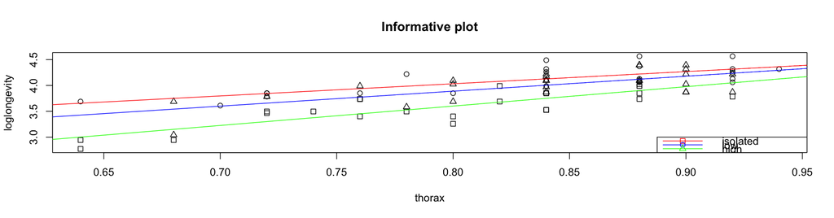

```r
plot(loglongevity~thorax, pch = c(0, 1, 2)[unclass(activity)], data=fruitflies, main="Informative plot")
legend("bottomright", legend=c("isolated","low","high"), col=c("red", "blue", "green"),lwd=1,pch = c(0, 1, 2))
abline(lm(loglongevity~thorax,data=fruitflies[c(1:25),]),col="red")
abline(lm(loglongevity~thorax,data=fruitflies[c(26:50),]),col="blue")
abline(lm(loglongevity~thorax,data=fruitflies[c(51:75),]),col="green")
```

However, none of the analysis is wrong. Both analysis are carried out according to the AN(C)OVA design. Although, it is more useful to include the explanatory variable thorax length, if it is known beforehand that thorax length has an influence on the longevity of fruitflies. This way the effect of the thorax length among different groups into account can be taken into account.

```r
summary(lm(loglongevity~thorax+activity,data=fruitflies))$adj.r.squared
summary(lm(loglongevity~activity,data=fruitflies))$adj.r.squared
```

0.709332153236789

0.332378386595666

Including thorax yields higher r2

```r
final_model = lm(formula = loglongevity ~ thorax + activity, data = fruitflies)
```

e.) Model assumptions

```
	Shapiro-Wilk normality test

data:  residuals(final_model)
W = 0.96838, p-value = 0.05748
```

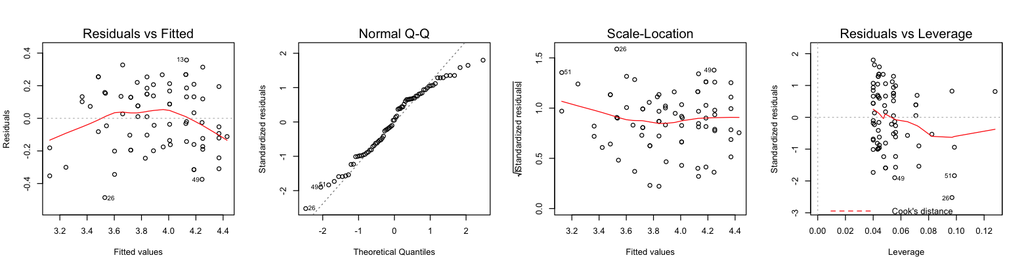

```r
options(repr.plot.width=13, repr.plot.height=3.4);par(mfrow=c(1,4
                                                            ));
plot(final_model);shapiro.test(residuals(final_model))
```

f.)

Perform the ancova analysis with the number of days as the response, rather than its logarithm. Verify normality and homoscedasticity of the residuals of this analysis. Was it wise to use the logarithm as response?

```r
full_model = lm(longevity~thorax+activity);
round(drop1(full_model, test="F"),5)
```

A anova: 3 × 6

|  | Df <dbl> | Sum of Sq <dbl> | RSS <dbl> | AIC <dbl> | F value <dbl> | Pr(>F) <dbl> |
| --- | --- | --- | --- | --- | --- | --- |
| <none> | NA | NA | 7672.994 | 355.0981 | NA | NA |
| thorax | 1 | 7686.766 | 15359.760 | 405.1514 | 71.12743 | 0 |
| activity | 2 | 4966.737 | 12639.731 | 388.5334 | 22.97918 | 0 |

Coefficients are still significant, but obviously the interpretation changes, since log is a non-linear mapping, we dont expect a 1:1 translation.

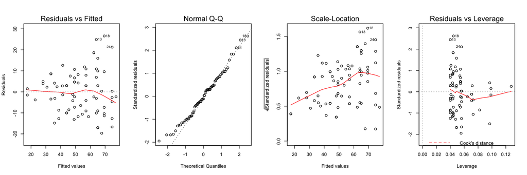

```r
par(mfrow=c(1,4));options(repr.plot.width=12, repr.plot.height=4)
plot(full_model)
```

The normality assumption is less violated than when using the transformed data, however the residuals show a clear sign of heteroscedasticity, essentially increasing having increased variations for larger values in y. We conclude that using the loglongevity is more appropiate because of the latter reason

#### 2.)

```r
df = read.table("titanic.txt",header=TRUE)
df$Sex = as.factor(df$Sex)
#df$Survived = as.factor(df$Survived)
df$PClass = as.factor(df$PClass);attach(df)
head(df,3)
```

A data.frame: 3 × 5

|  | Name <fct> | PClass <fct> | Age <dbl> | Sex <fct> | Survived <int> |
| --- | --- | --- | --- | --- | --- |
| 1 | Allen, Miss Elisabeth Walton | 1st | 29 | female | 1 |
| 2 | Allison, Miss Helen Loraine | 1st | 2 | female | 0 |
| 3 | Allison, Mr Hudson Joshua Creighton | 1st | 30 | male | 0 |

a) Study the data and give a few (>1) summaries (graphics or tables).

#### Survival ratios for individual factors

```r
success_prob_sex=xtabs(Survived~Sex)/xtabs(~Sex);
success_prob_sex
```

```
Sex
   female      male
0.6666667 0.1668625
```

```r
success_prob_pclass=xtabs(Survived~PClass)/xtabs(~PClass);
success_prob_pclass
```

```
PClass
      1st       2nd       3rd
0.5993789 0.4250000 0.1940928
```

#### Odds for individual factors

```r
odds_sex = success_prob_sex / (1-success_prob_sex);
odds_sex
```

```
Sex
   female      male
2.0000000 0.2002821
```

```r
odds_pclass = success_prob_pclass / (1-success_prob_pclass);odds_pclass
```

```
PClass
      1st       2nd       3rd
1.4961240 0.7391304 0.2408377
```

#### Survival ratios and odds for cross-factors

```r
success_prob = xtabs(Survived~PClass+Sex)/xtabs(~PClass+Sex);
success_prob
```

```
      Sex
PClass    female      male
   1st 0.9370629 0.3296089
   2nd 0.8785047 0.1445087
   3rd 0.3773585 0.1162325
```

```r
odds=success_prob/(1 - success_prob);
odds
```

```
      Sex
PClass     female       male
   1st 14.8888889  0.4916667
   2nd  7.2307692  0.1689189
   3rd  0.6060606  0.1315193
```

First of all we make the observation that approximately 60% of the 1st class survived the tragedy, while only 42.5% of the 2nd class and 19.4% of the 3rd class survived. This implies that the Passenger class is important when predicting if an individual survives. Next to that, we see that approximately 2/3 of all women survived, while only 16.66 % of men survived, indicating that females are having a much higher survival rate. The odds mirror these ratios very well (females = 2, males = 0.2!!) When looking at the cross-factor ratios, we can see that 93.7% of individuals who were female and 1st class, survived (Odds=14.8), while first class males only have odds of 0.49.

When it comes to the Age, we first have to say that 42% of the data is missing the Age variable. We therefore drop rows containing no data for Age. We think that using the global mean or any other method to impute the Age is a foolish approach. We rather use little data than imaginary data.

```r
df = na.omit(df[2:5]);attach(df)
```

```r
t.test(df[df$Survived==1,]$Age)$"conf.int"#CI age survivors
t.test(df[df$Survived==0,]$Age)$"conf.int"#CI age deceicved
```

1. 27.6571611615675

2. 31.062008167506

1. 29.8768221231751

2. 32.3865187346127

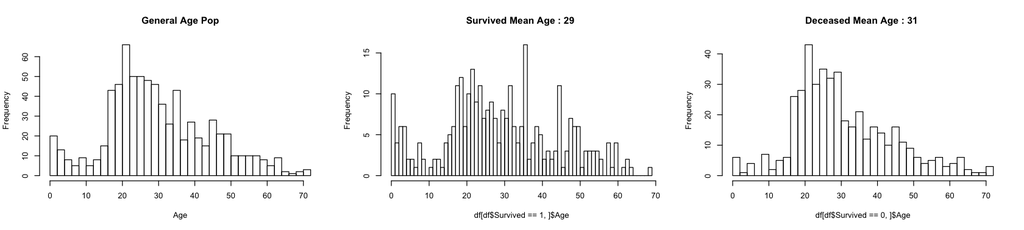

```r
par(mfrow=c(1,3));options(repr.plot.width=14, repr.plot.height=3.15);
hist(Age,breaks=50,main="General Age Pop");
hist(df[df$Survived==1,]$Age,breaks=50,main="Survived Mean Age : 29 ");
hist(df[df$Survived==0,]$Age,breaks=50,main="Deceased Mean Age : 31 ")
```

```r
mean(df[df$Age < 18,]$Survived)
mean(df[df$Age >= 18,]$Survived)
```

<NA>

<NA>

b) Fit a logistic regression model (no interactions yet) to investigate the association between the survival status and the predictors PClass, Age and Sex. Interpret the results in terms of odds, comment.

```r
model = glm(Survived~PClass+Sex+Age,family=binomial,data=df );
round(summary(model)$coefficients,3)
```

A matrix: 5 × 4 of type dbl

|  | Estimate | Std. Error | z value | Pr(>\|z\|) |
| --- | --- | --- | --- | --- |
| (Intercept) | 3.760 | 0.398 | 9.457 | 0 |
| PClass2nd | -1.292 | 0.260 | -4.968 | 0 |
| PClass3rd | -2.521 | 0.277 | -9.114 | 0 |
| Sexmale | -2.631 | 0.202 | -13.058 | 0 |
| Age | -0.039 | 0.008 | -5.144 | 0 |

- $\beta < 0 \implies \exp(\beta) <1$ (Decreases Odds)
- $\beta > 0 \implies \exp(\beta) >1$ (Increases Odds)

The gender has by far the lowest p-value, indicating a strong influence as we have already seen in the explanatory part. Being a male drastically decreases the linear predictor and the odds of surviving $\beta_{SEX} = -2.63$. Being 2nd or 3rd class ($\beta_{PC2} = -1.29$, $\beta_{PC3} = -2.52$) are also significantly decreasing the odds of surviving (i.e. multiplying the odds by $\exp(\beta)$, where $\exp(\beta) \ < 1 \ \forall \ \beta < 0$) yields lower odds. Increasing Age has a similar effect, $\exp(-0.03917681) = 0.961580677$, which looks like a small effect, but is almost deterministic for high ages, e.g. 70 yields $exp(70*-0.03917681)) \approx 0.06$, which is being multiplied to the odds (i.e increase in Age is associated with decrease in the probability of surviving)

Estimated Odds : exp(3.75 - 1.3 *PClass2nd - 2.52* PClass3rd - 2.63 *Sexmale - 0.04* Age)

c.1)

Investigate for interaction of predictor Age with factors PClass and Sex. From this and b), choose (and justify) a resulting model.

```r
model = glm(Survived~Sex+Age+PClass,family=binomial,data=df )
```

```r
model2 = glm(Survived~Sex+Age*PClass,family=binomial,data=df )
round(anova(model, model2, test="Chisq") ,3)
```

A anova: 2 × 5

|  | Resid. Df <dbl> | Resid. Dev <dbl> | Df <dbl> | Deviance <dbl> | Pr(>Chi) <dbl> |
| --- | --- | --- | --- | --- | --- |
| 1 | 751 | 695.141 | NA | NA | NA |
| 2 | 749 | 689.641 | 2 | 5.5 | 0.064 |

```r
model3 = glm(Survived~PClass+Age*Sex,family=binomial,data=df )
round(anova(model, model3, test="Chisq") ,3)
```

A anova: 2 × 5

|  | Resid. Df <dbl> | Resid. Dev <dbl> | Df <dbl> | Deviance <dbl> | Pr(>Chi) <dbl> |
| --- | --- | --- | --- | --- | --- |
| 1 | 751 | 695.141 | NA | NA | NA |
| 2 | 750 | 667.077 | 1 | 28.064 | 0 |

```r
#Equivalently
big_model = glm(Survived~Age*PClass+Age*Sex,family=binomial,data=df )
round(drop1(big_model,test="Chisq"),4)
```

A anova: 3 × 5

|  | Df <dbl> | Deviance <dbl> | AIC <dbl> | LRT <dbl> | Pr(>Chi) <dbl> |
| --- | --- | --- | --- | --- | --- |
| <none> | NA | 662.4471 | 678.4471 | NA | NA |
| Age:PClass | 2 | 667.0770 | 679.0770 | 4.6299 | 0.0988 |
| Age:Sex | 1 | 689.6408 | 703.6408 | 27.1937 | 0.0000 |

We see that the interaction between Age and PClass is non-significant ($p\approx 0.06$ when added to the model), while the interaction between Age and Gender is indeed significant when added to the model. We therefore include the interaction term Age*Sex into the model.

c.2) For this model, report the estimate for the probability of survival for each combination of levels of the factors PClass and Sex for a person of age 53.

```r
model = glm(Survived~PClass+Age*Sex,family=binomial,data=df )
round(summary(model,test="Chisq")$coefficients ,4)
```

A matrix: 6 × 4 of type dbl

|  | Estimate | Std. Error | z value | Pr(>\|z\|) |
| --- | --- | --- | --- | --- |
| (Intercept) | 2.7566 | 0.4376 | 6.2987 | 0.0000 |
| PClass2nd | -1.5434 | 0.2874 | -5.3709 | 0.0000 |
| PClass3rd | -2.6540 | 0.2914 | -9.1070 | 0.0000 |
| Age | 0.0024 | 0.0114 | 0.2142 | 0.8304 |
| Sexmale | -0.5082 | 0.4425 | -1.1484 | 0.2508 |
| Age:Sexmale | -0.0756 | 0.0150 | -5.0365 | 0.0000 |

Estimated Odds : exp(2.75 - 1.54 *PClass2nd - 2.65* PClass3rd + 0.002 *Age - 0.5* Sexmale -0.076 * Age:Sexmale )

```r
new.data <- data.frame(
    PClass = as.factor(c("1st","2nd","3rd","1st","2nd","3rd")),
    Sex = as.factor(c("female","female","female","male","male","male")),
    Age = c(53,53,53,53,53,53)
)
predict(model,new.data, type="response")
```

**1**

0.947153389276497

**2**

0.792933761334168

**3**

0.557762692707417

**4**

0.164042033984289

**5**

0.0402399835757588

**6**

0.0136208897536035

Estimated probabilites

- P(y=1 | 1/f/53) = 0.94
- P(y=1 | 2/f/53) = 0.79
- P(y=1 | 3/f/53) = 0.55
- P(y=1 | 1/m/53) = 0.16
- P(y=1 | 2/m/53) = 0.04
- P(y=1 | 3/m/53) = 0.01

d)

Propose a method to predict the survival status and a quality measure for your prediction and describe how you would implement that method (you do not need to implement it).

We would first use a randomly shuffled portion (e.g 80%) of the data to fit the model and use the model to predict the outcome of the other 20% of the data (the test set). To compare the predicted probability of survival with the actual outcome of the test set, we implement a threshold for our predictions, for example "1 if predicted >= 0.5". Then, we can obtain the accuary of that model by looking at the percent of correctly classified obervations.

e)

Another approach would be to apply a contingency table test to investigate whether factor passenger class (and gender) has an effect on the survival status. Implement the relevant test(s).

```r
df = read.table("titanic.txt",header=TRUE)
df$Sex = as.factor(df$Sex)
df$PClass = as.factor(df$PClass);#attach(df)
head(df,3)
```

A data.frame: 3 × 5

|  | Name <fct> | PClass <fct> | Age <dbl> | Sex <fct> | Survived <int> |
| --- | --- | --- | --- | --- | --- |
| 1 | Allen, Miss Elisabeth Walton | 1st | 29 | female | 1 |
| 2 | Allison, Miss Helen Loraine | 1st | 2 | female | 0 |
| 3 | Allison, Mr Hudson Joshua Creighton | 1st | 30 | male | 0 |

There are actually multiple ways to deploy a contingency table test, the most simple would be to test factor by factor using the chisq test for PClass/Survival and the fisher test for Sex/Survival.

```r
#Create contingency table
sex_survived = xtabs(~Survived+Sex)
sex_survived
```

```
        Sex
Survived female male
       0    154  709
       1    308  142
```

```r
fisher.test(sex_survived)#2x2
```

```
	Fisher's Exact Test for Count Data

data:  sex_survived
p-value < 2.2e-16
alternative hypothesis: true odds ratio is not equal to 1
95 percent confidence interval:
 0.07620521 0.13155709
sample estimates:
odds ratio
 0.1003494
```

$H_0$ is rejected. We cannot assume independence of gender and survival (i.e true odds ratio is not equal to 1).

```r
#Create contingency table
class_survived = xtabs(~Survived+PClass)
class_survived
```

```
        PClass
Survived 1st 2nd 3rd
       0 129 161 573
       1 193 119 138
```

```r
chisq.test(class_survived)
```

```
	Pearson's Chi-squared test

data:  class_survived
X-squared = 172.3, df = 2, p-value < 2.2e-16
```

$H_0$ is rejected. We cannot assume independence of PClass and survival.

```r
chisq.test(class_survived)$expected > 5
```

A matrix: 2 × 3 of type lgl

|  | 1st | 2nd | 3rd |
| --- | --- | --- | --- |
| 0 | TRUE | TRUE | TRUE |
| 1 | TRUE | TRUE | TRUE |

f)

Is the second approach in e) wrong? Name both an advantage and a disadvantage of the two approaches, relative to each other.

Using contingency table is generally not entirely incorrect as it its straight forward in what it can measure/answer (i.e homogenity/independence). The logistic regression model has the huge advantage that it can take any set of covariates (numerical or/and factorial) and map their linear combination onto a probability space, which is not only handy for interpretation, but also very useful when it is desired to deploy the model for the usage of out of sample predictions.

#### 3.)

```r
df = read.table("africa.txt",header=TRUE);
df$pollib = as.factor(df$pollib);attach(df)
head(df,3)
```

A data.frame: 3 × 9

|  | miltcoup <int> | oligarchy <int> | pollib <fct> | parties <int> | pctvote <dbl> | popn <dbl> | size <dbl> | numelec <int> | numregim <int> |
| --- | --- | --- | --- | --- | --- | --- | --- | --- | --- |
| Benin | 5 | 7 | 1 | 34 | 45.68 | 4.6 | 113 | 8 | 3 |
| Burkina | 6 | 13 | 2 | 62 | 17.50 | 8.8 | 274 | 5 | 3 |
| Burundi | 2 | 13 | 2 | 10 | 34.39 | 5.3 | 28 | 3 | 3 |

a)

Perform Poisson regression on the full data set africa, taking miltcoup as response variable, Comment on your findings.

```r
model = glm(miltcoup~oligarchy+pollib+parties+pctvote+popn+size+numelec+numregim,family=poisson);
round(drop1(model, test="Chisq"),3)
```

A anova: 9 × 5

|  | Df <dbl> | Deviance <dbl> | AIC <dbl> | LRT <dbl> | Pr(>Chi) <dbl> |
| --- | --- | --- | --- | --- | --- |
| <none> | NA | 28.249 | 113.058 | NA | NA |
| oligarchy | 1 | 32.354 | 115.163 | 4.105 | 0.043 |
| pollib | 2 | 35.581 | 116.390 | 7.331 | 0.026 |
| parties | 1 | 35.311 | 118.120 | 7.062 | 0.008 |
| pctvote | 1 | 30.572 | 113.380 | 2.322 | 0.128 |
| popn | 1 | 30.601 | 113.410 | 2.351 | 0.125 |
| size | 1 | 29.238 | 112.046 | 0.988 | 0.320 |
| numelec | 1 | 28.430 | 111.239 | 0.181 | 0.670 |
| numregim | 1 | 29.059 | 111.868 | 0.810 | 0.368 |

```r
round(summary(model)$coefficients,3)
```

A matrix: 10 × 4 of type dbl

|  | Estimate | Std. Error | z value | Pr(>\|z\|) |
| --- | --- | --- | --- | --- |
| (Intercept) | -0.233 | 0.998 | -0.234 | 0.815 |
| oligarchy | 0.073 | 0.035 | 2.053 | 0.040 |
| pollib1 | -1.103 | 0.656 | -1.682 | 0.093 |
| pollib2 | -1.690 | 0.677 | -2.498 | 0.012 |
| parties | 0.031 | 0.011 | 2.796 | 0.005 |
| pctvote | 0.015 | 0.010 | 1.528 | 0.126 |
| popn | 0.011 | 0.007 | 1.533 | 0.125 |
| size | 0.000 | 0.000 | -0.985 | 0.324 |
| numelec | -0.030 | 0.070 | -0.425 | 0.671 |
| numregim | 0.211 | 0.234 | 0.902 | 0.367 |

```r
exp(summary(model)$coefficients)[,1]
```

**(Intercept)**

0.791815076117505

**oligarchy**

1.07526352995339

**pollib1**

0.331793035860825

**pollib2**

0.184463119227982

**parties**

1.03171364809909

**pctvote**

1.01556108307231

**popn**

1.01101881922597

**size**

0.999734961080741

**numelec**

0.970815817663923

**numregim**

1.2348422370741

- exp($\alpha$) = exp(-0.233427404) = 0.79 is the effect on the mean of miltcoup ($\mu$), when all X = 0 and pollib_level=0
- exp($\beta_i$) = with every unit increase in $X_i$, the predictor has a multiplicative effect of exp($\beta_i$) on the mean of miltcoup ($\mu$).
- If $\beta_i$ = 0, then exp($\beta_i$) = 1, and the expected count is exp($\alpha$), i.e miltcoup and the predictor are not related.
- If $\beta_i$ > 0, then exp($\beta_i$) > 1, and the expected count is exp($\beta_i$) times larger than when $X_i$ = 0
- If $\beta_i$ < 0, then exp($\beta_i$) < 1, and the expected count is exp($\beta_i$) times smaller than when $X_i$ = 0

We see that only parties, pollib_2 and oligarchy have significant, i.e significant non-zero coefficients according to the poission model.

- For pollib_level = 0 and X = 0 for all other variables, expected count is exp($\alpha$) = exp(-0.233427404) = 0.79
- pollib_level = 2 decreases the expected count (multiplicative) by exp(-1.690305731)=0.184.
- parties increases the expected count (multiplicative) by exp(0.031221156) = 1.031
- oligarchy increases the expected count (multiplicative) by exp(0.072565776) = 1.075

Conclusion : The political liberalization level has the biggest and most dramatic impact on the occurence of military coups.

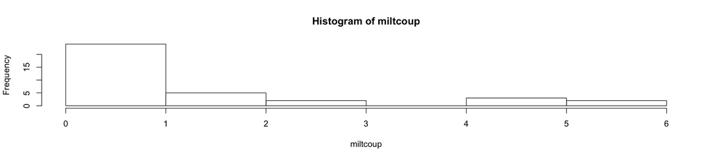

```r
hist(miltcoup)
```

```r
mean(miltcoup); var(miltcoup)
```

1.58333333333333

3.10714285714286

We see that the data is clearly non-normal and exhibits a poisson-like distribution of rare events (counts). Also, we see variance and mean are not equal, indicating slight over-dispersion in the fit of the model.

b)

Use the step down approach (using output of the function summary) to reduce the number of explanatory variables. Compare the resulting model with your findings in a).

```r
#model = glm(miltcoup~oligarchy+pollib+parties+pctvote+popn+size+numelec+numregim,family=poisson);summary(model)
#1.) Drop Numelec
#model = glm(miltcoup~oligarchy+pollib+parties+pctvote+popn+size+numregim,family=poisson);summary(model)
#2.) Drop Numregime
#model = glm(miltcoup~oligarchy+pollib+parties+pctvote+popn+size,family=poisson);summary(model)
#3.) Drop size
#model = glm(miltcoup~oligarchy+pollib+parties+pctvote+popn,family=poisson);summary(model)
#4.) Drop popn
#model = glm(miltcoup~oligarchy+pollib+parties,family=poisson);summary(model)
#5.) Drop pctvote
model = glm(miltcoup~oligarchy+pollib+parties,family=poisson);
summary(model)
```

```
Call:
glm(formula = miltcoup ~ oligarchy + pollib + parties, family = poisson)

Deviance Residuals:
    Min       1Q   Median       3Q      Max
-1.3609  -1.0407  -0.3153   0.6145   1.7536

Coefficients:
             Estimate Std. Error z value Pr(>|z|)
(Intercept)  0.207981   0.445679   0.467   0.6407
oligarchy    0.091466   0.022563   4.054 5.04e-05 ***
pollib1     -0.495414   0.475645  -1.042   0.2976
pollib2     -1.112086   0.459492  -2.420   0.0155 *
parties      0.022358   0.009098   2.458   0.0140 *
---
Signif. codes:  0 ‘***’ 0.001 ‘**’ 0.01 ‘*’ 0.05 ‘.’ 0.1 ‘ ’ 1

(Dispersion parameter for poisson family taken to be 1)

    Null deviance: 65.945  on 35  degrees of freedom
Residual deviance: 32.822  on 31  degrees of freedom
AIC: 107.63

Number of Fisher Scoring iterations: 5
```

```r
exp(summary(model)$coefficients)[,1]
```

**(Intercept)**

1.23118980453107

**oligarchy**

1.09578003866221

**pollib1**

0.609318469003076

**pollib2**

0.32887206016355

**parties**

1.02260970217993

We end up with `miltcoup~oligarchy+pollib+parties`, which is consistent with what we found earlier, meaning the selected predictors are significant compared to the remaining predictors. In this model, we can interprete the estimates as follows:

- exp($\alpha$) = exp(0.207981) = 1.23 is the effect on the mean of Y $\mu$, when X = 0 and pollib_level = 0
- pollib_level = 1 decreases the expected count (multiplicative) by 0.60
- pollib_level = 2 decreases the expected count (multiplicative) by 0.32
- parties increases the expected count (multiplicative) by 1.022
- oligarchy increases the expected count (multiplicative) by 1.095

Conclusion : The model is similar to what we would have expected already : Level of politcal liberalization is very important when determining potential military coups

c)

Predict the number of coups for a hypothetical country for all the three levels of political liberalization and the averages (over all the counties in the data) of all the other (numerical) characteristics. Comment on your findings.

```r
mean(oligarchy);mean(parties)
```

5.22222222222222

17.0833333333333

```r
new.data <- data.frame(
    oligarchy = c(5.222,5.222,5.222),#mean
    pollib = as.factor(c(0,1,2)),
    parties = c(17.08,17.08,17.08)#mean
)
predict(model, new.data, type="response")
```

**1**

2.90807611336105

**2**

1.77194448513757

**3**

0.956384982513458

Using the selected model `miltcoup~oligarchy+pollib+parties`, we predict 2.9 (3) coups for pollib=0, 1.77 (2) coups for pollib=1 and 0.95 (1) coups if pollib=2. The counts of occurences of a military coup is primarly determined by the level of political liberalization, according to our model.

```r
new.data <- data.frame(
    oligarchy = c(0),
    pollib = as.factor(c(0)),
    parties = c(0)
)
predict(model, new.data, type="response")
```

**1:** 1.23118980453107